# **FIFA 2022 World Cup Data Analysis**

**Author:** Dessailly Kikuku  
**Goal:** Turn raw World Cup 2022 match stats into clear insights for readers who may be new to **Python** and **soccer analytics**.

**What you’ll learn**

- How to read and explore tabular data with **pandas**
- Soccer basics: goals, attempts, possession, cards, etc.
- How to reshape matches into **team-level** records for analysis
- How to build clean, interpretable charts and write takeaways
- How to export a shareable HTML/PDF report

> This notebook blends **education** (what each step means) with a **professional narrative** (why it matters and what we learned).

## Setup: Libraries & Style

We load Python libraries:

- **pandas** for tables and grouping
- **numpy** for simple numeric helpers
- **matplotlib / seaborn** for charts

We also set global style options so every chart looks consistent and readable. If you see “FutureWarning” messages (version hints), we can hide them for a cleaner, report-ready notebook.

> **Why hide warnings?**  
> Warnings are helpful for developers, but they distract non-technical readers.  
> For a teaching/report version, we suppress them globally so charts stand out.

## Load the Dataset

We load the CSV file that has **64 World Cup 2022 matches** with detailed stats. Each row = one match (Team 1 vs Team 2) with columns such as:

- `number of goals team1` / `team2` — goals scored
- `possession team1` / `team2` — % of ball control
- `total attempts ...` and `on target attempts ...` — shots and shots on goal
- passes completed, cards (yellow/red), corners, fouls, etc.

After loading, we preview a few rows to confirm columns and values look correct.

`.info()` shows data types and missing values.  
`.describe()` gives quick stats like averages and ranges.  
This helps us see if the data is clean.

## Understand the Data: Columns & Types

Before analysis, we answer:

- What columns exist and what do they mean?
- Are columns numeric or text?
- Are there missing values?

This step helps us avoid surprises and choose the right operations for each column.

```
<class 'pandas.core.frame.DataFrame'>
RangeIndex: 64 entries, 0 to 63
Data columns (total 88 columns):
 #   Column                                                 Non-Null Count  Dtype
---  ------                                                 --------------  -----
 0   team1                                                  64 non-null     object
 1   team2                                                  64 non-null     object
 2   possession team1                                       64 non-null     object
 3   possession team2                                       64 non-null     object
 4   possession in contest                                  64 non-null     object
 5   number of goals team1                                  64 non-null     int64
 6   number of goals team2                                  64 non-null     int64
 7   date                                                   64 non-null     object
 8   hour                                                   64 non-null     object
 9   category                                               64 non-null     object
```

[output cut: 80 more lines]

|  | count | unique | top | freq | mean | std | min | 25% | 50% | 75% | max |
| --- | --- | --- | --- | --- | --- | --- | --- | --- | --- | --- | --- |
| team1 | 64 | 32 | ARGENTINA | 5 | NaN | NaN | NaN | NaN | NaN | NaN | NaN |
| team2 | 64 | 32 | MOROCCO | 4 | NaN | NaN | NaN | NaN | NaN | NaN | NaN |
| possession team1 | 64 | 32 | 51% | 5 | NaN | NaN | NaN | NaN | NaN | NaN | NaN |
| possession team2 | 64 | 34 | 35% | 5 | NaN | NaN | NaN | NaN | NaN | NaN | NaN |
| possession in contest | 64 | 11 | 13% | 12 | NaN | NaN | NaN | NaN | NaN | NaN | NaN |
| number of goals team1 | 64.0 | NaN | NaN | NaN | 1.578125 | 1.551289 | 0.0 | 0.0 | 1.0 | 2.0 | 7.0 |
| number of goals team2 | 64.0 | NaN | NaN | NaN | 1.109375 | 1.055856 | 0.0 | 0.0 | 1.0 | 2.0 | 4.0 |
| date | 64 | 23 | 22 NOV 2022 | 4 | NaN | NaN | NaN | NaN | NaN | NaN | NaN |
| hour | 64 | 5 | 20 : 00 | 24 | NaN | NaN | NaN | NaN | NaN | NaN | NaN |
| category | 64 | 13 | Round of 16 | 8 | NaN | NaN | NaN | NaN | NaN | NaN | NaN |
| total attempts team1 | 64.0 | NaN | NaN | NaN | 11.140625 | 4.972519 | 2.0 | 8.0 | 10.0 | 14.0 | 25.0 |
| total attempts team2 | 64.0 | NaN | NaN | NaN | 11.28125 | 5.807682 | 0.0 | 7.75 | 10.0 | 14.0 | 32.0 |
| conceded team1 | 64.0 | NaN | NaN | NaN | 1.109375 | 1.055856 | 0.0 | 0.0 | 1.0 | 2.0 | 4.0 |
| conceded team2 | 64.0 | NaN | NaN | NaN | 1.578125 | 1.551289 | 0.0 | 0.0 | 1.0 | 2.0 | 7.0 |
| goal inside the penalty area team1 | 64.0 | NaN | NaN | NaN | 1.46875 | 1.563155 | 0.0 | 0.0 | 1.0 | 2.0 | 7.0 |
| goal inside the penalty area team2 | 64.0 | NaN | NaN | NaN | 0.984375 | 0.999876 | 0.0 | 0.0 | 1.0 | 2.0 | 4.0 |
| goal outside the penalty area team1 | 64.0 | NaN | NaN | NaN | 0.09375 | 0.293785 | 0.0 | 0.0 | 0.0 | 0.0 | 1.0 |
| goal outside the penalty area team2 | 64.0 | NaN | NaN | NaN | 0.109375 | 0.314576 | 0.0 | 0.0 | 0.0 | 0.0 | 1.0 |
| assists team1 | 64.0 | NaN | NaN | NaN | 1.171875 | 1.363407 | 0.0 | 0.0 | 1.0 | 2.0 | 6.0 |
| assists team2 | 64.0 | NaN | NaN | NaN | 0.734375 | 0.895176 | 0.0 | 0.0 | 1.0 | 1.0 | 4.0 |

|  | team1 | team2 | possession team1 | possession team2 | possession in contest | number of goals team1 | number of goals team2 | date | hour | category | total attempts team1 | total attempts team2 | conceded team1 | conceded team2 | goal inside the penalty area team1 | goal inside the penalty area team2 | goal outside the penalty area team1 | goal outside the penalty area team2 | assists team1 | assists team2 | on target attempts team1 | on target attempts team2 | off target attempts team1 | off target attempts team2 | attempts inside the penalty area team1 | attempts inside the penalty area team2 | attempts outside the penalty area team1 | attempts outside the penalty area team2 | left channel team1 | … |
| --- | --- | --- | --- | --- | --- | --- | --- | --- | --- | --- | --- | --- | --- | --- | --- | --- | --- | --- | --- | --- | --- | --- | --- | --- | --- | --- | --- | --- | --- | --- |
| 0 | QATAR | ECUADOR | 42% | 50% | 8% | 0 | 2 | 20 NOV 2022 | 17 : 00 | Group A | 5 | 6 | 2 | 0 | 0 | 2 | 0 | 0 | 0 | 1 | 0 | 3 | 5 | 3 | 2 | 4 | 3 | 2 | 15 | … |
| 1 | ENGLAND | IRAN | 72% | 19% | 9% | 6 | 2 | 21 NOV 2022 | 14 : 00 | Group B | 13 | 8 | 2 | 6 | 6 | 2 | 0 | 0 | 6 | 1 | 7 | 3 | 3 | 4 | 10 | 6 | 3 | 2 | 11 | … |
| 2 | SENEGAL | NETHERLANDS | 44% | 45% | 11% | 0 | 2 | 21 NOV 2022 | 17 : 00 | Group A | 14 | 9 | 2 | 0 | 0 | 2 | 0 | 0 | 0 | 1 | 3 | 3 | 8 | 5 | 7 | 5 | 7 | 4 | 12 | … |
| 3 | UNITED STATES | WALES | 51% | 39% | 10% | 1 | 1 | 21 NOV 2022 | 20 : 00 | Group B | 6 | 7 | 1 | 1 | 1 | 1 | 0 | 0 | 1 | 0 | 1 | 3 | 4 | 3 | 4 | 5 | 2 | 2 | 14 | … |
| 4 | ARGENTINA | SAUDI ARABIA | 64% | 24% | 12% | 1 | 2 | 22 NOV 2022 | 11 : 00 | Group C | 14 | 3 | 2 | 1 | 1 | 2 | 0 | 0 | 0 | 1 | 6 | 2 | 5 | 0 | 10 | 3 | 4 | 0 | 12 | … |

## Reshape: From Match Rows to Team Rows

Each match row has two teams. To compare teams fairly, we create **one row per team per match**:

- Rename columns so that the current team’s stats are always called `goals_for`, `attempts_team`, etc.
- Build two DataFrames (team1’s view and team2’s view), then stack them.
- Add a `result` label: **W** (win), **D** (draw), **L** (loss) based on goals.

This transformation lets us group by team later (e.g., total goals in the tournament).

```
<class 'pandas.core.frame.DataFrame'>
RangeIndex: 64 entries, 0 to 63
Data columns (total 18 columns):
 #   Column                    Non-Null Count  Dtype
---  ------                    --------------  -----
 0   date                      64 non-null     object
 1   category                  64 non-null     object
 2   team1                     64 non-null     object
 3   team2                     64 non-null     object
 4   number of goals team1     64 non-null     int64
 5   number of goals team2     64 non-null     int64
 6   possession team1          64 non-null     object
 7   possession team2          64 non-null     object
 8   total attempts team1      64 non-null     int64
 9   total attempts team2      64 non-null     int64
 10  on target attempts team1  64 non-null     int64
 11  on target attempts team2  64 non-null     int64
 12  yellow cards team1        64 non-null     int64
 13  yellow cards team2        64 non-null     int64
 14  red cards team1           64 non-null     int64
 15  red cards team2           64 non-null     int64
 16  passes completed team1    64 non-null     int64
 17  passes completed team2    64 non-null     int64
dtypes: int64(12), object(6)
memory usage: 9.1+ KB
```

|  | date | category | team1 | team2 | number of goals team1 | number of goals team2 | possession team1 | possession team2 | total attempts team1 | total attempts team2 | on target attempts team1 | on target attempts team2 | yellow cards team1 | yellow cards team2 | red cards team1 | red cards team2 | passes completed team1 | passes completed team2 |
| --- | --- | --- | --- | --- | --- | --- | --- | --- | --- | --- | --- | --- | --- | --- | --- | --- | --- | --- |
| 0 | 20 NOV 2022 | Group A | QATAR | ECUADOR | 0 | 2 | 42% | 50% | 5 | 6 | 0 | 3 | 4 | 2 | 0 | 0 | 381 | 409 |
| 1 | 21 NOV 2022 | Group B | ENGLAND | IRAN | 6 | 2 | 72% | 19% | 13 | 8 | 7 | 3 | 0 | 2 | 0 | 0 | 730 | 154 |
| 2 | 21 NOV 2022 | Group A | SENEGAL | NETHERLANDS | 0 | 2 | 44% | 45% | 14 | 9 | 3 | 3 | 2 | 1 | 0 | 0 | 313 | 374 |
| 3 | 21 NOV 2022 | Group B | UNITED STATES | WALES | 1 | 1 | 51% | 39% | 6 | 7 | 1 | 3 | 4 | 2 | 0 | 0 | 509 | 321 |
| 4 | 22 NOV 2022 | Group C | ARGENTINA | SAUDI ARABIA | 1 | 2 | 64% | 24% | 14 | 3 | 6 | 2 | 0 | 6 | 0 | 0 | 529 | 190 |

|  | date | category | team | opponent | goals_for | goals_against | possession_team | possession_opp | attempts_team | attempts_opp | ontarget_team | ontarget_opp | yellow_team | yellow_opp | red_team | red_opp | passes_team | passes_opp | result |
| --- | --- | --- | --- | --- | --- | --- | --- | --- | --- | --- | --- | --- | --- | --- | --- | --- | --- | --- | --- |
| 0 | 20 NOV 2022 | Group A | QATAR | ECUADOR | 0 | 2 | 42% | 50% | 5 | 6 | 0 | 3 | 4 | 2 | 0 | 0 | 381 | 409 | L |
| 1 | 21 NOV 2022 | Group B | ENGLAND | IRAN | 6 | 2 | 72% | 19% | 13 | 8 | 7 | 3 | 0 | 2 | 0 | 0 | 730 | 154 | W |
| 2 | 21 NOV 2022 | Group A | SENEGAL | NETHERLANDS | 0 | 2 | 44% | 45% | 14 | 9 | 3 | 3 | 2 | 1 | 0 | 0 | 313 | 374 | L |
| 3 | 21 NOV 2022 | Group B | UNITED STATES | WALES | 1 | 1 | 51% | 39% | 6 | 7 | 1 | 3 | 4 | 2 | 0 | 0 | 509 | 321 | D |
| 4 | 22 NOV 2022 | Group C | ARGENTINA | SAUDI ARABIA | 1 | 2 | 64% | 24% | 14 | 3 | 6 | 2 | 0 | 6 | 0 | 0 | 529 | 190 | L |

## Team Summary: Wins, Goals, Points

Now we condense each team’s performance across the tournament:

- **Games** played, **Wins/Draws/Losses**
- **Goals For/Against** and **Goal Difference**
- **Points** (3 per win, 1 per draw)
- Average **Attempts** and **Passes** per match
- A possession value we’ll convert to % later

This acts like a mini “league table” for the whole World Cup.

|  | team | games | wins | draws | losses | goals_for | goals_against | attempts | passes | possession | points | goal_diff |
| --- | --- | --- | --- | --- | --- | --- | --- | --- | --- | --- | --- | --- |
| 11 | FRANCE | 7 | 5 | 1 | 1 | 16 | 8 | 14.428571 | 456.000000 | 56% | 16 | 8 |
| 0 | ARGENTINA | 7 | 4 | 2 | 1 | 15 | 8 | 14.857143 | 548.714286 | 64% | 14 | 7 |
| 19 | NETHERLANDS | 5 | 3 | 2 | 0 | 10 | 4 | 8.000000 | 488.400000 | 48% | 11 | 6 |
| 18 | MOROCCO | 7 | 3 | 2 | 2 | 6 | 5 | 8.714286 | 317.000000 | 32% | 11 | 1 |
| 10 | ENGLAND | 5 | 3 | 1 | 1 | 13 | 4 | 12.000000 | 544.600000 | 72% | 10 | 9 |
| 3 | BRAZIL | 5 | 3 | 1 | 1 | 8 | 3 | 18.000000 | 539.200000 | 53% | 10 | 5 |
| 7 | CROATIA | 7 | 2 | 4 | 1 | 8 | 7 | 11.571429 | 532.000000 | 41% | 10 | 1 |
| 21 | PORTUGAL | 5 | 3 | 0 | 2 | 12 | 6 | 12.400000 | 523.000000 | 55% | 9 | 6 |
| 15 | JAPAN | 4 | 2 | 1 | 1 | 5 | 4 | 10.500000 | 324.500000 | 48% | 7 | 1 |
| 24 | SENEGAL | 4 | 2 | 0 | 2 | 5 | 7 | 12.750000 | 319.000000 | 44% | 6 | -2 |

## Who Performed Best? — Top 10 Teams by Points

**Why this matters:** Points summarize consistency in soccer (result-driven performance).  
**How to read:** Bars to the right = more tournament points.

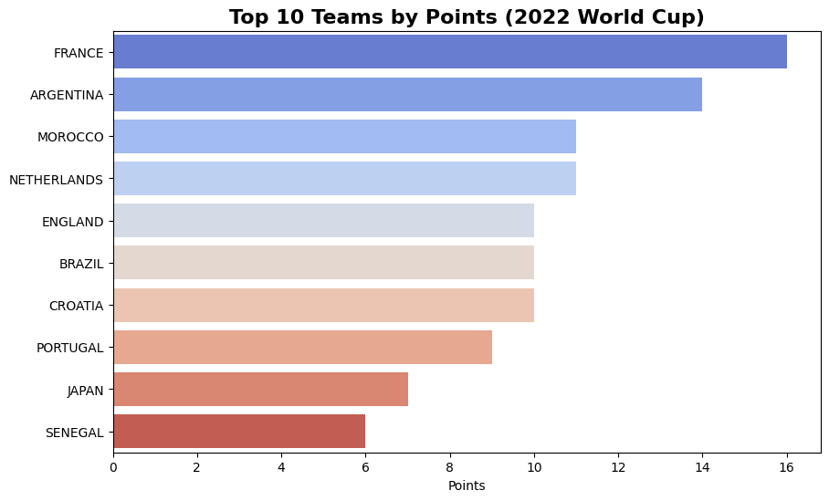

**What we see:**

- The leaders reflect strong group stages and knockouts.
- Look for surprises (e.g., a team with fewer total goals still ranking high due to tight wins).

## Can You Turn Chances into Goals? — Offensive Efficiency

Shots (attempts) are opportunities; goals are the outcome.  
A team high on goals with **fewer** attempts = **efficient finishing**;  
a team high on attempts but low on goals may struggle with conversion.

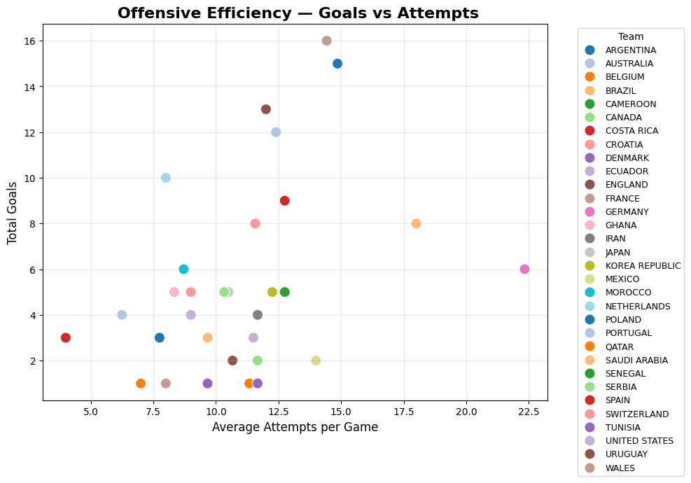

**Takeaway:**  
Which teams sit **above** the general trend? Those are converting chances well.  
Teams far right but not very high may need better shot quality/finishing.

## Discipline — Yellow and Red Cards

Cards indicate physicality and risk:

- **Yellow** = caution for unsporting behavior
- **Red** = player sent off (team plays with fewer players)

Higher card totals can reflect a physical style or matches under pressure.

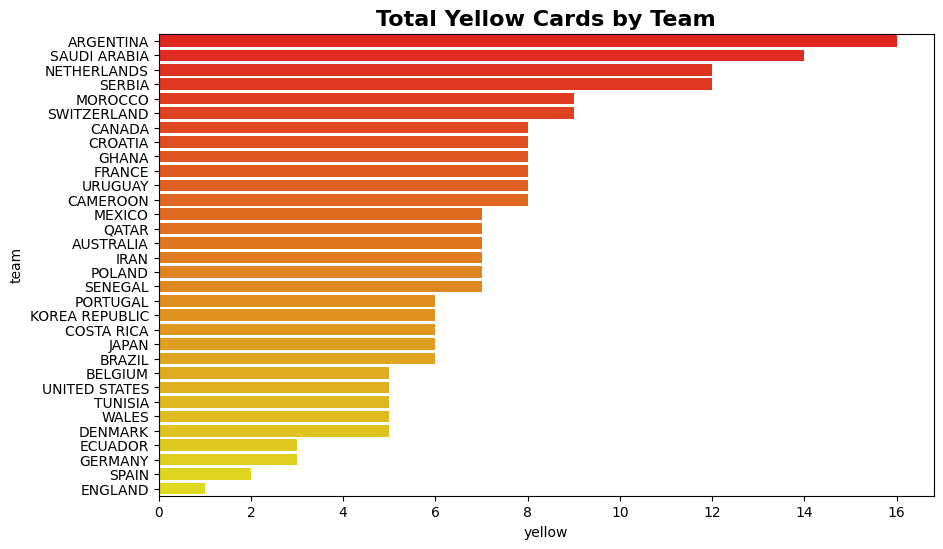

**Interpretation:**  
Compare high-card teams to their results. Did discipline issues correlate with fewer points or key match incidents?

## Does Possession Translate to Success?

**Possession** measures time on the ball.  
Some teams dominate the ball; others prefer **compact defense + counter-attacks**.  
We compare **average possession** with **total tournament points**.

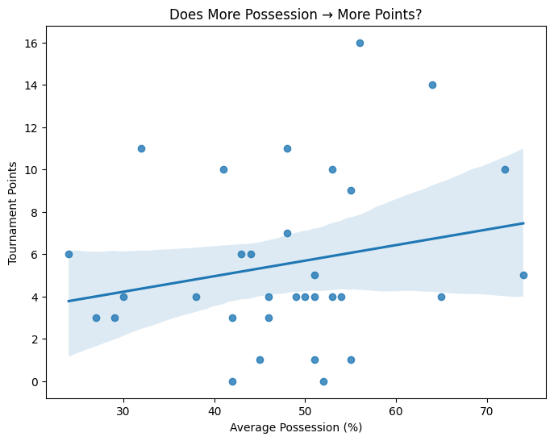

**Insight:**  
Possession alone isn’t destiny. Efficient transitions and finishing matter.  
Teams can earn results with less possession if they create better chances.

## Which teams scored the most goals?

This reveals which countries contributed most to scoring. But does scoring more goals means success?

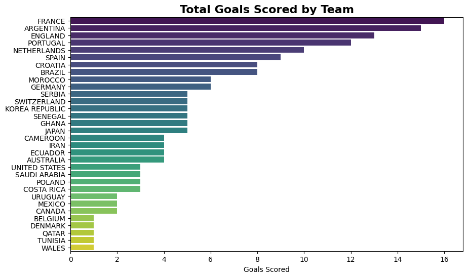

### What This Chart Tells Us

- Teams at the top of the chart—such as **France**, **England**, and **Argentina**—scored the highest number of goals.  
  This often reflects strong attacking lines, efficient finishing, and deep tournament runs.
- Mid-table teams may have balanced scoring, showing tactical approaches that combine offense and structure.
- Nations near the bottom typically struggled to create or finish chances, or faced stronger opponents early in the tournament.

### Extra Insight

A team’s goal total doesn’t tell the full story (e.g., defensive teams may advance with fewer goals),  
but it **does** reveal which sides posed the biggest attacking threats throughout the competition.

If paired with “Goals Conceded” or “Goal Difference,” you get an even clearer picture of overall strength.

## Goal Difference — Measuring Net Team Performance

**Goal Difference (GD)** = *Goals Scored − Goals Conceded*

It’s one of the simplest but most powerful soccer indicators.  
A **positive GD** means the team scored more than they conceded — a sign of both strong attack and solid defense.  
A **negative GD** suggests defensive weaknesses or struggles in finishing chances.

This chart compares the *net performance* of each team to show who dominated and who struggled during the tournament.

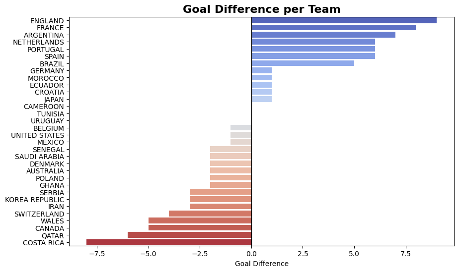

### What This Shows

- Teams **above the center line (positive GD)** consistently outscored opponents — they controlled matches both offensively and defensively.
- Teams **below zero (negative GD)** likely struggled to convert chances or defend against stronger opponents.

In the 2022 World Cup, **France**, **Argentina**, and **England** stood out with high goal differences, reflecting both attacking firepower and defensive structure.  
Meanwhile, early exits with negative GD often came from teams that conceded heavily or lost multiple close matches.

> **Interpretation Tip:**  
> Goal Difference summarizes efficiency — a few big wins can inflate it, but steady small margins often show true consistency.

## Goals Timeline — Which Matchdays Were the Most Explosive?

Tournaments often have moments where the action peaks — days with many goals, dramatic matches, or decisive group outcomes.  
A **timeline visualization** helps us understand:

- How goal scoring changed throughout the competition
- Whether early group-stage matches or knockout rounds had more goals
- Which specific days were the most exciting for fans

This also helps explain shifts in team behavior:  
early matches may be cautious, while later stages push teams to attack aggressively.

By plotting total goals per date, we can see the rhythm of the tournament and identify high-impact matchdays.

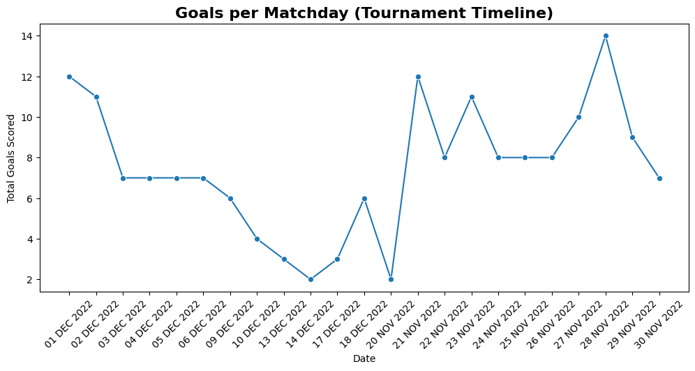

### What This Timeline Reveals

- **Peaks** in the chart represent matchdays with multiple high-scoring games.  
  These are usually group-stage days with 3–4 matches played.
- **Dips** in goal totals often occur during the knockout rounds,  
  where teams play more cautiously because a single mistake can eliminate them.
- The trend helps us understand the competition’s flow:  
  early excitement, tactical adjustments, and high-intensity elimination matches.

### Why This Matters

Seeing goals over time tells a *story* about how the tournament evolved —  
from the chaotic, attacking early days to the tightly contested matches near the end.

This timeline also helps pinpoint which days were the most memorable  
for fans and analysts tracking the drama of the World Cup.

```
Teams with missing region info:
Series([], Name: team, dtype: object)
```

|  | region | goals_for |
| --- | --- | --- |
| 0 | Africa | 21 |
| 1 | Asia | 22 |
| 2 | Europe | 90 |
| 3 | North America | 10 |
| 4 | South America | 29 |

## Where Did the Goals Come From? — Continents

We assign each nation to a **continent/region** and sum total goals per region.  
This reveals which parts of the world contributed most to scoring.

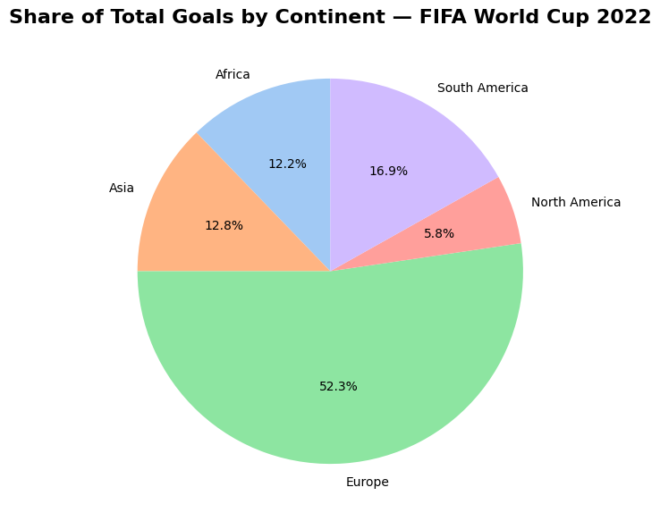

**Reading the pie:**  
Regions with larger slices scored more goals overall.  
This doesn’t prove “better teams,” but shows scoring distribution by confederation.

# Summary & Next Steps

You learned how to:

- load and clean soccer data
- summarize wins, goals, and possession
- visualize team and continent performance

### Next Challenges

- Add player-level data (goals, assists)
- Predict winners using machine learning
- Compare 2022 vs 2018 World Cup

```
[NbConvertApp] Converting notebook /content/drive/MyDrive/Colab Notebooks/Fifa_2022_Analysis.ipynb to html
[NbConvertApp] WARNING | Alternative text is missing on 8 image(s).
[NbConvertApp] Writing 899598 bytes to /content/Fifa_2022_Report.html
```